# Ass3

#### Q1. Define Natural Language Processing (NLP). Provide three real-world applications of NLP and explain how they impact society.

**Natural Language Processing (NLP)** is a branch of artificial intelligence that focuses on the interaction between computers and human languages. It involves programming computers to process, analyze, and understand large amounts of natural language data.

**Real-World Applications & Impact**:

- **Machine Translation (e.g., Google Translate)** = Breaks down language barriers, allowing for global communication and access to information in various languages.
- **Sentiment Analysis** = Used by companies to analyze customer feedback or social media trends, helping businesses understand public perception and improve services.
- **Virtual Assistants (e.g., Siri, Alexa)** = Enhances accessibility and efficiency by allowing users to interact with technology using natural voice commands

#### Q2. Explain the following terms and their significance in NLP:

1. Tokenization
2. Stemming
3. Lemmatization
- **Tokenization** = The process of breaking down a text into smaller units called "tokens," such as words or sentences. It is the foundational step for almost all NLP tasks.
- **Stemming** = A rule-based process that chops off the ends of words to find the "root" form (e.g., "running" becomes "run"). It helps in normalizing words, though it can sometimes result in non-dictionary words.
- **Lemmatization** = Similar to stemming but more sophisticated; it uses vocabulary and morphological analysis to return the dictionary form of a word, known as a lemma (e.g., "better" becomes "good").

#### Q3. What is Part-of-Speech (POS) tagging? Discuss its importance with an example.

**POS tagging** is the process of marking up a word in a text as corresponding to a particular part of speech (noun, verb, adjective, etc.) based on its definition and context.  
**Importance**: It is crucial for understanding the grammatical structure and meaning of a sentence. For example, in the sentences "I can a fruit" vs. "I have a can," POS tagging identifies the first "can" as a verb and the second as a noun, which is vital for accurate translation or summarization.

#### Q4. Create a TextBlob named exercise blob containing ”This is a TextBlob”.

```python
from textblob import TextBlob
exercise_blob = TextBlob("This is a TextBlob")
exercise_blob
```

```
TextBlob("This is a TextBlob")
```

#### Q5. Write a Python script to perform the following tasks on the given text:

- Tokenize the text into words and sentences.
- Perform stemming and lemmatization using NLTK or SpaCy.
- Remove stop words from the text.
- Sample Text: "Natural Language Processing enables machines to understand and process human languages. It is a fascinating field with numerous applications, such as chatbots and language translation."

```python
import spacy

nlp = spacy.load("en_core_web_sm")

text = "Natural Language Processing enables machines to understand and process human languages. It is a fascinating field with numerous applications, such as chatbots and language translation."

doc = nlp(text)

words = [token.text for token in doc]
sentences = [sent.text for sent in doc.sents]

filtered_tokens = [token for token in doc if not token.is_stop and not token.is_punct]
lemmatized_words = [token.lemma_ for token in filtered_tokens]

print("Original Words:", words)
print("Sentences:", sentences)
print("Filtered & Lemmatized Words:", lemmatized_words)
```

```
Original Words: ['Natural', 'Language', 'Processing', 'enables', 'machines', 'to', 'understand', 'and', 'process', 'human', 'languages', '.', 'It', 'is', 'a', 'fascinating', 'field', 'with', 'numerous', 'applications', ',', 'such', 'as', 'chatbots', 'and', 'language', 'translation', '.']
Sentences: ['Natural Language Processing enables machines to understand and process human languages.', 'It is a fascinating field with numerous applications, such as chatbots and language translation.']
Filtered & Lemmatized Words: ['Natural', 'Language', 'processing', 'enable', 'machine', 'understand', 'process', 'human', 'language', 'fascinating', 'field', 'numerous', 'application', 'chatbot', 'language', 'translation']
```

#### Q6. Web Scraping with the Requests and Beautiful Soup Libraries:

- Use the requests library to download the www.python.org home page’s content.
- Use the Beautiful Soup library to extract only the text from the page.
- Eliminate the stop words in the resulting text, then use the wordcloud module to create a wordcloud based on the text.

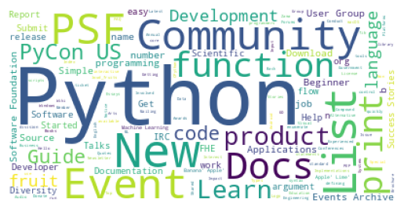

```python
import requests
from bs4 import BeautifulSoup
from wordcloud import WordCloud
import matplotlib.pyplot as plt
from nltk.corpus import stopwords

res = requests.get('https://www.python.org')
soup = BeautifulSoup(res.text, 'html.parser')
raw_text = soup.get_text()

stops = set(stopwords.words('english'))
wc = WordCloud(stopwords=stops, background_color="white").generate(raw_text)

plt.imshow(wc)
plt.axis("off")
plt.show()
```

#### Q7. (Tokenizing Text and Noun Phrases) Using the text from above problem, create a TextBlob, then tokenize it into Sentences and Words, and extract its noun phrases.

```python
from textblob import TextBlob

blob = TextBlob(raw_text)
sentences = blob.sentences
words = blob.words
noun_phrases = blob.noun_phrases

print(sentences[:2])
print(words[:2])
print(noun_phrases[:2])
```

```
[Sentence("




























Welcome to Python.org




















Notice: This page displays a fallback because interactive scripts did not run."), Sentence("Possible causes include disabled JavaScript or failure to load scripts or stylesheets.")]
['Welcome', 'to']
['welcome', 'python.org notice']
```

#### Q8. (Sentiment of a News Article) Using the techniques in problem no. 5, download a web page for a current news article and create a TextBlob. Display the sentiment for the entire TextBlob and for each Sentence.

```python
import requests
from bs4 import BeautifulSoup
from textblob import TextBlob

url = 'https://www.bbc.com/news/articles/clyp24j7nqdo'
html = requests.get(url).text
soup = BeautifulSoup(html, 'html.parser')
text = soup.get_text()

blob = TextBlob(text)
print(blob.sentiment)

for sentence in blob.sentences:
    print(sentence.sentiment)
```

```
Sentiment(polarity=0.12429527836504581, subjectivity=0.37764857881136954)
Sentiment(polarity=0.0, subjectivity=0.0)
Sentiment(polarity=0.0, subjectivity=0.0)
Sentiment(polarity=0.05576923076923078, subjectivity=0.3378205128205129)
Sentiment(polarity=0.18409090909090908, subjectivity=0.3916666666666666)
Sentiment(polarity=0.2, subjectivity=0.2)
Sentiment(polarity=0.171969696969697, subjectivity=0.4241161616161616)
Sentiment(polarity=0.0, subjectivity=0.0)
Sentiment(polarity=-0.05, subjectivity=0.325)
Sentiment(polarity=0.0, subjectivity=0.1)
```

#### Q9. (Sentiment of a News Article with the NaiveBayesAnalyzer) Repeat the previous exercise but use the NaiveBayesAnalyzer for sentiment analysis.

```python
from textblob import TextBlob
from textblob.sentiments import NaiveBayesAnalyzer

blob_nb = TextBlob(text, analyzer=NaiveBayesAnalyzer())
print(blob_nb.sentiment)

for sentence in blob_nb.sentences:
    print(sentence.sentiment)
```

```
Sentiment(classification='pos', p_pos=1.0, p_neg=2.6187586498026565e-21)
Sentiment(classification='neg', p_pos=0.3204291660223993, p_neg=0.6795708339776017)
Sentiment(classification='pos', p_pos=0.5, p_neg=0.5)
Sentiment(classification='pos', p_pos=0.9999999868756934, p_neg=1.3124313568481826e-08)
Sentiment(classification='pos', p_pos=0.9994869643714028, p_neg=0.0005130356286055419)
Sentiment(classification='pos', p_pos=0.9995227763552366, p_neg=0.00047722364475887095)
Sentiment(classification='pos', p_pos=0.9999999999071716, p_neg=9.283159316493604e-11)
Sentiment(classification='pos', p_pos=0.6473189248463977, p_neg=0.35268107515360264)
Sentiment(classification='pos', p_pos=0.9103077734528857, p_neg=0.0896922265471128)
Sentiment(classification='neg', p_pos=0.42886703710495666, p_neg=0.5711329628950439)
```

#### Q10. (Spell Check a Project Gutenberg Book) Download a Project Gutenberg book and create a TextBlob. Tokenize the TextBlob into Words and determine whether any are misspelled. If so, display the possible corrections

```python
import requests
from textblob import TextBlob
from textblob import Word

url = "https://www.gutenberg.org/files/1342/1342-0.txt"
text = requests.get(url).text[:1000]
blob = TextBlob(text)

for word in blob.words:
    w = Word(word.lower())
    suggestions = w.spellcheck()
    if suggestions[0][1] < 1.0:
        print(w, suggestions)
```

```
ruskin [('skin', 0.4150537634408602), ('russian', 0.33046594982078853), ('russia', 0.13835125448028673), ('tushin', 0.053763440860215055), ('ruin', 0.034408602150537634), ('rushing', 0.014336917562724014), ('muslin', 0.0035842293906810036), ('rustic', 0.002150537634408602), ('russen', 0.001433691756…
saintsbury [('saintsbury', 0.0)]
ruskin [('skin', 0.4150537634408602), ('russian', 0.33046594982078853), ('russia', 0.13835125448028673), ('tushin', 0.053763440860215055), ('ruin', 0.034408602150537634), ('rushing', 0.014336917562724014), ('muslin', 0.0035842293906810036), ('rustic', 0.002150537634408602), ('russen', 0.001433691756…
```

#### Q11.

- Write a Python program that takes user input in English and translates it to French, Spanish, and German using TextBlob.
- Create a program that takes multiple user-inputted sentences, analyzes polarity and subjectivity, and categorizes them as objective/subjective and positive/negative/neutral Develop a function that takes a paragraph, splits it into sentences, and calculates the sentiment score for each sentence individually.
- Write a program that takes a sentence as input and prints each word along with its POS tag using TextBlob.
- Create a function that takes a user-inputted word, checks its spelling using TextBlob, and suggests top 3 closest words if a mistake is found.
- Build a Python script that extracts all adjectives from a given paragraph and prints them in order of occurrence.
- Write a program that takes a news article as input and extracts the top 5 most common noun phrases as keywords.
- Write a program that takes a news article as input and extracts the top 5 most common noun phrases as keywords.
- Write a program that summarizes a given paragraph by keeping only the most informative sentences, based on noun phrase frequency.

```python
from textblob import TextBlob, Word
from collections import Counter
import nltk
from deep_translator import GoogleTranslator

nltk.download('punkt')
nltk.download('averaged_perceptron_tagger')

def translate_text():
    text = input("Enter English text: ")

    print("French:", GoogleTranslator(source='en', target='fr').translate(text))
    print("Spanish:", GoogleTranslator(source='en', target='es').translate(text))
    print("German:", GoogleTranslator(source='en', target='de').translate(text))

def sentiment_analysis():
    n = int(input("How many sentences? "))
    for i in range(n):
        s = input(f"Sentence {i+1}: ")
        blob = TextBlob(s)

        polarity = blob.sentiment.polarity
        subjectivity = blob.sentiment.subjectivity

        if polarity > 0:
            sentiment = "Positive"
        elif polarity < 0:
            sentiment = "Negative"
        else:
            sentiment = "Neutral"

        obj_type = "Subjective" if subjectivity > 0.5 else "Objective"

        print(f"\n{s}")
        print("Sentiment:", sentiment)
        print("Type:", obj_type)

def sentence_sentiment():
    text = input("Enter paragraph: ")
    blob = TextBlob(text)

    for sentence in blob.sentences:
        print(sentence)
        print("Sentiment:", sentence.sentiment)

def pos_tagging():
    text = input("Enter sentence: ")
    blob = TextBlob(text)

    for word, tag in blob.tags:
        print(word, "->", tag)

def spell_check():
    word = input("Enter word: ")
    w = Word(word)

    if w.spellcheck()[0][0] == word:
        print("Correct spelling")
    else:
        print("Top suggestions:")
        for s in w.spellcheck()[:3]:
            print(s[0])

def extract_adjectives():
    text = input("Enter paragraph: ")
    blob = TextBlob(text)

    adjectives = [w for w, t in blob.tags if t.startswith("JJ")]
    print("Adjectives:", adjectives)

def noun_phrases():
    text = input("Enter article: ")
    blob = TextBlob(text)

    counts = Counter(blob.noun_phrases)

    print("Top 5 noun phrases:")
    for w, c in counts.most_common(5):
        print(w, ":", c)

def summarize():
    text = input("Enter paragraph: ")
    blob = TextBlob(text)

    np_counts = Counter(blob.noun_phrases)
    scores = {}

    for sentence in blob.sentences:
        score = 0
        for np in np_counts:
            if np in sentence.lower():
                score += np_counts[np]
        scores[sentence] = score

    top = sorted(scores, key=scores.get, reverse=True)[:3]

    print("\nSummary:")
    for s in top:
        print(s)

while True:
    print("\n===== NLP MENU =====")
    print("1. Translate Text")
    print("2. Sentiment Analysis (multiple sentences)")
    print("3. Sentence-wise Sentiment")
    print("4. POS Tagging")
    print("5. Spell Check")
    print("6. Extract Adjectives")
    print("7. Noun Phrase Keywords")
    print("8. Summarization")
    print("9. Exit")

    choice = input("Enter choice: ")

    if choice == "1":
        translate_text()
    elif choice == "2":
        sentiment_analysis()
    elif choice == "3":
        sentence_sentiment()
    elif choice == "4":
        pos_tagging()
    elif choice == "5":
        spell_check()
    elif choice == "6":
        extract_adjectives()
    elif choice == "7":
        noun_phrases()
    elif choice == "8":
        summarize()
    elif choice == "9":
        print("Exiting...")
        break
    else:
        print("Invalid choice")
```

```
===== NLP MENU =====
1. Translate Text
2. Sentiment Analysis (multiple sentences)
3. Sentence-wise Sentiment
4. POS Tagging
5. Spell Check
6. Extract Adjectives
7. Noun Phrase Keywords
8. Summarization
9. Exit
```

```
Enter choice: 1
Enter English text: hello i am human
French: bonjour, je suis humain
Spanish: hola soy humano
German: Hallo, ich bin ein Mensch

===== NLP MENU =====
1. Translate Text
2. Sentiment Analysis (multiple sentences)
3. Sentence-wise Sentiment
4. POS Tagging
5. Spell Check
6. Extract Adjectives
7. Noun Phrase Keywords
8. Summarization
9. Exit
Enter choice: 2
How many sentences? 1
Sentence 1: hello i am human

hello i am human
Sentiment: Neutral
Type: Objective

===== NLP MENU =====
1. Translate Text
2. Sentiment Analysis (multiple sentences)
3. Sentence-wise Sentiment
4. POS Tagging
5. Spell Check
6. Extract Adjectives
7. Noun Phrase Keywords
8. Summarization
9. Exit
Enter choice: 9
Exiting...
```

#### Q12. Write a Python program that takes a word as input and returns:

- Its definition
- Its synonyms
- Its antonyms(if available)

```python
from nltk.corpus import wordnet

def word_info(word):
    synonyms = set()
    antonyms = set()
    definition = None

    for syn in wordnet.synsets(word):
        if definition is None:
            definition = syn.definition()

        for lemma in syn.lemmas():
            synonyms.add(lemma.name())

            if lemma.antonyms():
                for ant in lemma.antonyms():
                    antonyms.add(ant.name())

    print("\nWord:", word)

    print("\nDefinition:")
    print(definition if definition else "No definition found")

    print("\nSynonyms:")
    print(", ".join(synonyms) if synonyms else "None found")

    print("\nAntonyms:")
    print(", ".join(antonyms) if antonyms else "None found")



w = input("Enter a word: ")
word_info(w)
```

```
Enter a word: good

Word: good

Definition:
benefit

Synonyms:
in_effect, just, dependable, soundly, practiced, adept, proficient, safe, well, serious, estimable, goodness, right, near, thoroughly, honest, secure, skillful, unspoiled, good, in_force, commodity, full, dear, unspoilt, salutary, honorable, ripe, upright, beneficial, effective, undecomposed, trade_…

Antonyms:
evil, badness, evilness, ill, bad
```

#### Q13.

- Write a Python program that reads a .txt file, processes the text, and generates a word cloud visualization.
- Create a word cloud in the shape of an object (e.g., a heart, star) using WordCloud and a mask image.

[figure not shown]

```python
from wordcloud import WordCloud, STOPWORDS
import matplotlib.pyplot as plt

file_path = "RomeoAndJuliet.txt"

with open(file_path, "r", encoding="utf-8") as file:
    text = file.read()

stopwords = set(STOPWORDS)

wc = WordCloud(
    width=800,
    height=400,
    background_color="white",
    stopwords=stopwords
).generate(text)

plt.figure(figsize=(10,5))
plt.imshow(wc, interpolation="bilinear")
plt.axis("off")
plt.show()
```

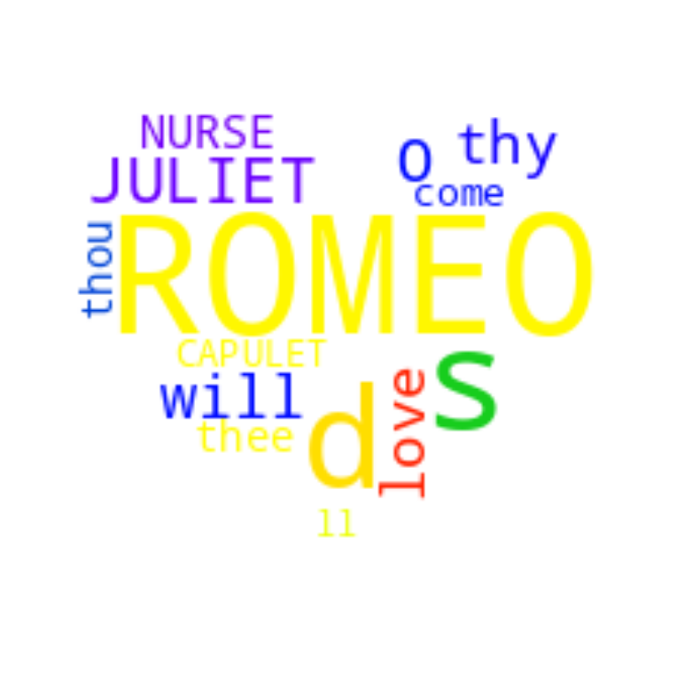

```python
import imageio.v2 as imageio
import numpy as np
from wordcloud import WordCloud
from pathlib import Path
import matplotlib.pyplot as plt

text = Path('RomeoAndJuliet.txt').read_text(encoding='utf-8')

mask_image = imageio.imread('heart.png')

mask_image = np.where(mask_image > 128, 255, 0)

wordcloud = WordCloud(
    colormap='prism',
    mask=mask_image,
    background_color='white'
).generate(text)

wordcloud.to_file('mask_heart2.png')

plt.figure(figsize=(10,10))
plt.imshow(wordcloud, interpolation='bilinear')
plt.axis('off')
plt.show()
```

#### Q14. (Textatistic: Readability of News Articles) Using the above techniques, download from several news sites current news articles on the same topic. Perform readability assessments on them to determine which sites are the most readable. For each article, calculate the average number of words per sentence, the average number of characters per word and the average number of syllables per word.

```python
import re

def count_syllables(word):
    word = word.lower()
    word = re.sub(r'[^a-z]', '', word)

    vowels = "aeiouy"
    count = 0
    prev_vowel = False

    for char in word:
        is_vowel = char in vowels
        if is_vowel and not prev_vowel:
            count += 1
        prev_vowel = is_vowel

    if word.endswith("e") and count > 1:
        count -= 1

    return max(1, count)

from nltk.tokenize import sent_tokenize, word_tokenize
import requests
from bs4 import BeautifulSoup

def analyze_article(url):
    headers = {"User-Agent": "Mozilla/5.0"}
    html = requests.get(url, headers=headers).text
    soup = BeautifulSoup(html, "html.parser")

    # extract text
    text = soup.get_text(separator=" ")

    sentences = sent_tokenize(text)
    words = word_tokenize(text)

    words = [w for w in words if w.isalpha()]

    if len(sentences) == 0 or len(words) == 0:
        return None

    # metrics
    avg_words_per_sentence = len(words) / len(sentences)

    avg_chars_per_word = sum(len(w) for w in words) / len(words)

    avg_syllables_per_word = sum(count_syllables(w) for w in words) / len(words)

    return {
        "sentences": len(sentences),
        "words": len(words),
        "avg_words_per_sentence": avg_words_per_sentence,
        "avg_chars_per_word": avg_chars_per_word,
        "avg_syllables_per_word": avg_syllables_per_word
    }

urls = [
    "https://www.bbc.com/news/world-us-canada-66231862",
    "https://www.theguardian.com/world/2024/example",
    "https://www.reuters.com/world/example"
]

for url in urls:
    print("\n====================")
    print("URL:", url)

    result = analyze_article(url)

    if result:
        print("Sentences:", result["sentences"])
        print("Words:", result["words"])
        print("Avg words/sentence:", round(result["avg_words_per_sentence"], 2))
        print("Avg chars/word:", round(result["avg_chars_per_word"], 2))
        print("Avg syllables/word:", round(result["avg_syllables_per_word"], 2))
    else:
        print("Could not extract article text")
```

```
====================
URL: https://www.bbc.com/news/world-us-canada-66231862
Sentences: 17
Words: 658
Avg words/sentence: 38.71
Avg chars/word: 5.17
Avg syllables/word: 1.71

====================
URL: https://www.theguardian.com/world/2024/example
Sentences: 4
Words: 44
Avg words/sentence: 11.0
Avg chars/word: 4.07
Avg syllables/word: 1.36

====================
URL: https://www.reuters.com/world/example
Sentences: 1
Words: 8
Avg words/sentence: 8.0
Avg chars/word: 4.5
Avg syllables/word: 1.5
```

#### Q15. (spaCy: Named Entity Recognition) Using the above techniques, download a current news article, then use the spaCy library’s named entity recognition capabilities to display the named entities (people, places, organizations, etc.) in the article.

```python
import requests
from bs4 import BeautifulSoup
import spacy

nlp = spacy.load("en_core_web_sm")

url = "https://www.bbc.com/news/world-us-canada-66231862"

headers = {"User-Agent": "Mozilla/5.0"}
html = requests.get(url, headers=headers).text

soup = BeautifulSoup(html, "html.parser")

paragraphs = soup.find_all("p")
text = " ".join([p.get_text() for p in paragraphs])

doc = nlp(text)

print("\n===== NAMED ENTITIES =====\n")

for ent in doc.ents:
    print(ent.text, "->", ent.label_)
```

```
===== NAMED ENTITIES =====

Jayne Charles's -> PERSON
third -> ORDINAL
the Wolverhampton MS Therapy Centre -> ORG
Jay House -> PERSON
two weeks -> DATE
Aberystwyth -> ORG
Hereford -> PERSON
Veolia -> GPE
Fenn's Bank -> ORG
Wrexham -> PERSON
A year -> DATE
Beryl -> GPE
Bertie -> PERSON
Shrewsbury -> WORK_OF_ART
Old River Bed -> LOC
2026 -> DATE
BBC -> ORG
BBC -> ORG
```

#### Q16. (spaCy: Shakespeare Similarity Detection) Using the spaCy techniques, download a Shakespeare comedy from Project Gutenberg and compare it for similarity with Romeo and Juliet.

```python
import requests
import spacy
from bs4 import BeautifulSoup

nlp = spacy.load("en_core_web_md")

def get_text(url):
    headers = {"User-Agent": "Mozilla/5.0"}
    html = requests.get(url, headers=headers).text
    soup = BeautifulSoup(html, "html.parser")
    return soup.get_text()

def clean(text):
    return " ".join(text.split())

romeo_url = "https://www.gutenberg.org/cache/epub/1513/pg1513.txt"
romeo_text = clean(get_text(romeo_url))

comedy_url = "https://www.gutenberg.org/cache/epub/1514/pg1514.txt"
comedy_text = clean(get_text(comedy_url))

doc1 = nlp(romeo_text[:200000])
doc2 = nlp(comedy_text[:200000])

similarity_score = doc1.similarity(doc2)

print("\n===== SHAKESPEARE SIMILARITY =====")
print("Romeo & Juliet vs Comedy")
print("Similarity Score:", similarity_score)
```

```
===== SHAKESPEARE SIMILARITY =====
Romeo & Juliet vs Comedy
Similarity Score: 0.9980871677398682
```

#### Q17. (textblob.utils Utility Functions) Use strip punc and lowerstrip functions of TextBlob’s textblob.utils module with all=True keyword argument to remove punctuation and to get a string in all lowercase letters with whitespace and punctuation removed. Experiment with each function on Romeo and Juliet.

```python
from pathlib import Path
from textblob import TextBlob
from textblob.utils import strip_punc, lowerstrip

text = Path("RomeoAndJuliet.txt").read_text(encoding="utf-8")

blob = TextBlob(text)

print("\n===== ORIGINAL TEXT SAMPLE =====\n")
print(text[:800])

clean_punc = strip_punc(text, all=True)

print("\n===== AFTER strip_punc(all=True) =====\n")
print(clean_punc[:800])

clean_lower = lowerstrip(text, all=True)

print("\n===== AFTER lowerstrip(all=True) =====\n")
print(clean_lower[:800])

print("\n===== TEXT STATISTICS =====\n")

print("Original length:", len(text))
print("After strip_punc:", len(clean_punc))
print("After lowerstrip:", len(clean_lower))

print("\n===== SAMPLE WORD COMPARISON =====\n")

print("Original words:", text.split()[:20])
print("Clean words:", clean_lower.split()[:20])
```

```
===== ORIGINAL TEXT SAMPLE =====

The Project Gutenberg eBook of Romeo and Juliet

This eBook is for the use of anyone anywhere in the United States and
most other parts of the world at no cost and with almost no restrictions
whatsoever. You may copy it, give it away or re-use it under the terms
of the Project Gutenberg License included with this eBook or online
at www.gutenberg.org. If you are not located in the United States,
you will have to check the laws of the country where you are located
before using this eBook.

Title: Romeo and Juliet

Author: William Shakespeare



Release date: November 1, 1998 [eBook #1513]
                Most recently updated: September 18, 2025

Language: English

Other information and formats: www.gutenberg.org/ebooks/1513

Credits: the PG Shakespeare Team, a team of about twen

===== AFTER strip_punc(all=True) =====

The Project Gutenberg eBook of Romeo and Juliet

This eBook is for the use of anyone anywhere in the United States and
most other parts of the world at no cost and with almost no restrictions
whatsoever You may copy it give it away or reuse it under the terms
of the Project Gutenberg License included with this eBook or online
at wwwgutenbergorg If you are not located in the United States
you will have to check the laws of the country where you are located
before using this eBook

Title Romeo and Juliet
```

[output cut: 36 more lines]

```

other information and formats wwwgutenbergorgebooks1513

credits the pg shakespeare team a team of about twenty project gutenberg volu

===== TEXT STATISTICS =====

Original length: 161818
After strip_punc: 154422
After lowerstrip: 154422

===== SAMPLE WORD COMPARISON =====

Original words: ['The', 'Project', 'Gutenberg', 'eBook', 'of', 'Romeo', 'and', 'Juliet', 'This', 'eBook', 'is', 'for', 'the', 'use', 'of', 'anyone', 'anywhere', 'in', 'the', 'United']
Clean words: ['the', 'project', 'gutenberg', 'ebook', 'of', 'romeo', 'and', 'juliet', 'this', 'ebook', 'is', 'for', 'the', 'use', 'of', 'anyone', 'anywhere', 'in', 'the', 'united']
```